# COMP4211_Assignment2

```python
import os
import torch
import pandas as pd
import numpy as np
import matplotlib.pyplot as plt
from sklearn.preprocessing import LabelEncoder
import torchvision
import tensorboard
```

```python
device = torch.device('cuda' if torch.cuda.is_available() else 'cpu')
print(device)
```

```
cuda
```

```python
PATH = '/home/glarbsten/Desktop/Spring2021/COMP4211/Assignments/Assignment2/pa2/' # path to this file
!ls '/home/glarbsten/Desktop/Spring2021/COMP4211/Assignments/Assignment2/pa2/'
```

```
1Data			    Data  index.txt   sub	train.csv
COMP4211_Assignment2.ipynb  Desc  README.txt  test.csv	valid.csv
```

```python
header_list = ["index", "location"]
index_content = pd.read_csv(PATH + 'index.txt', delimiter = ",", names = header_list)

index_content
```

|  | index | location |
| --- | --- | --- |
| 0 | 1 | Data/Images/001/frontal/01.jpg |
| 1 | 2 | Data/Images/001/frontal/02.jpg |
| 2 | 3 | Data/Images/001/frontal/03.jpg |
| 3 | 4 | Data/Images/001/frontal/04.jpg |
| 4 | 5 | Data/Images/001/frontal/05.jpg |
| ... | ... | ... |
| 4995 | 4996 | Data/Images/test/t471.jpg |
| 4996 | 4997 | Data/Images/test/t472.jpg |
| 4997 | 4998 | Data/Images/test/t473.jpg |
| 4998 | 4999 | Data/Images/test/t474.jpg |
| 4999 | 5000 | Data/Images/test/t475.jpg |

5000 rows × 2 columns

```python
# files
test_csv = os.path.join(PATH, 'test.csv')
validation_csv = os.path.join(PATH, 'valid.csv')
train_csv = os.path.join(PATH, 'train.csv')
```

```python
train_data = pd.read_csv(train_csv)
valid_data = pd.read_csv(validation_csv)
test_data = pd.read_csv(test_csv)
```

```python
print(train_data.shape)
print(valid_data.shape)
print(test_data.shape)
```

```
(4900, 3)
(700, 3)
(700, 3)
```

```python
from PIL import Image # for images
```

# 4.2.1 Dataset and Data Loader

```python
import torchvision.transforms as transforms
from torch.utils.data import Dataset
from torch.utils.data import DataLoader
```

```python
#train dataset class
class CSV_Dataset(Dataset):
  #constructor
    def __init__(self, PATH, csv_file, transform = None): # PATH is assignment2 path along with the name of the csv_file that needs to be extracted
        #transformations applied
        self.transform = transform

        #file paths (train, valid, test, index)
        self.csv_path = os.path.join(PATH, csv_file)
        self.index_txt = os.path.join(PATH, 'index.txt')

        #file data (train, valid, test)
        self.csv_data = pd.read_csv(self.csv_path)


        #index.txt file content
        header_list = ["picture_num", "location"]
        self.index_content = pd.read_csv(self.index_txt, delimiter = ",", names = header_list)

        #preprocessing: resizing all the images to a size of 32x32 and converting them to single-channel images
        #extract id1 and id2 from train_data
        for row in self.csv_data.index:
            id1_id2_loc = [self.index_content['location'][self.csv_data["id1"][row] - 1], self.index_content['location'][self.csv_data['id2'][row] - 1]]
             # -1 coz indexing starts from 0
            for i in id1_id2_loc:
                image = Image.open(PATH + i).convert("LA") # converting to single-channel image
                image = image.resize((32,32)).convert("RGB") # resizing and converting to RGB to process the image for saving
                #transformations
                imgage = self.transform(image)
                image.save(PATH + i) # saving/replacing the images


    def __getitem__(self, idx): # change it
        img1 = Image.open(PATH + self.index_content["location"][self.csv_data["id1"][idx] - 1])  # gets the image object from id1 of index.txt file
        img2 = Image.open(PATH + self.index_content["location"][self.csv_data["id2"][idx] - 1])  # same but for id2
        #transformations
        img1 = self.transform(img1)
        img2 = self.transform(img2)

        # label

        if self.csv_data["target"][idx] == 0 or self.csv_data["target"][idx] == 1:
            label = self.csv_data["target"][idx]
            # gets the target label i.e. 0 (if they match) or 1 (if they do not)
        else:
            label = -1  # label is not defined

        label = torch.as_tensor([label]).float()
        return img1, img2, label        #label = 0 or 1 if defined and -1 if not


    def __len__ (self):
        return len(self.csv_data)
```

```python
transform = transforms.Compose(
    [transforms.ToTensor(),    # range [0, 255]  -> [0.0,1.0] Convert a PIL Image or numpy.ndarray (H x W x C)  to tensor (C x H x W)
     transforms.Normalize((0.5, ), (0.5, )), # channel=（channel-mean）/std  -> [-1, 1]
     transforms.Grayscale(num_output_channels=1)
    ])
```

```python
train_dataset = CSV_Dataset(PATH, 'train.csv', transform)
valid_dataset = CSV_Dataset(PATH, 'valid.csv', transform)
test_dataset = CSV_Dataset(PATH, 'test.csv', transform)
```

```python
bs = 128 # batch size

train_loader = DataLoader(train_dataset, batch_size=bs, shuffle=True, num_workers=4, pin_memory=True)
valid_loader = DataLoader(valid_dataset, batch_size=bs, shuffle=False, num_workers=4, pin_memory=True)
```

```python
dataiter = iter(train_loader)
input1, input2, label1 = next(dataiter)
input3, input4, label2 = next(dataiter)
```

```python
input1.shape
```

```
torch.Size([128, 1, 32, 32])
```

```python
input2.shape
```

```
torch.Size([128, 1, 32, 32])
```

```python
# label1
```

# 4.2.2 Siamese Convolutional Neural Network

```python
import torch.nn as nn
import torch.nn.functional as F
import torch.optim as optim
```

```python
# (1x32x32)-> conv -> conv -> max pooling -> conv (64 kernels) -> conv (128 kernels) -> conv (256) -> conv (512)
# avg pooling (16*16 kernel size) -> flattening  -> output (1*512 vector)

class Net1(nn.Module):
    def __init__(self):
        super(Net1, self).__init__()

        # (32x32x1)-> conv -> (32x32x32) -> conv -> (32x32x32) ->  maxpool -> (16x16x32)
        # conv -> (16x16x64)-> conv (16x16x128) -> conv (16x16x256) -> conv (16x16x512)
        # avgpool -> (16x16x512) -> fc -> (1x1x512)
        self.conv1 = nn.Conv2d(in_channels=1, out_channels=32, kernel_size=3, padding=1, stride=1)
        self.conv2 = nn.Conv2d(in_channels=32, out_channels=32, kernel_size=3, padding=1, stride=1)

        # max pooling
        self.max_pool = nn.MaxPool2d(2, stride=2)

        self.conv3 = nn.Conv2d(in_channels=32, out_channels=64, kernel_size=3, padding=1, stride=1)
        self.conv4 = nn.Conv2d(in_channels=64, out_channels=128, kernel_size=3, padding=1, stride=1)
        self.conv5 = nn.Conv2d(in_channels=128, out_channels=256, kernel_size=3, padding=1, stride=1)
        self.conv6 = nn.Conv2d(in_channels=256, out_channels=512, kernel_size=3, padding=1, stride=1)

        # average pooling
        self.avg_pool = nn.AvgPool2d(16, stride=1)

        # batch normalization
        self.norm1 = nn.BatchNorm2d(32)
        self.norm2 = nn.BatchNorm2d(32)
        self.norm3 = nn.BatchNorm2d(64)
        self.norm4 = nn.BatchNorm2d(128)
        self.norm5 = nn.BatchNorm2d(256)
        self.norm6 = nn.BatchNorm2d(512)



    def forward(self, img1, img2):
        #  1, 32, 32
        # out_dim = in_dim - kernel_size + 1

        img1 = F.relu((self.norm1(self.conv1(img1)))) #32, 32, 32
        img1 = self.max_pool(F.relu(self.norm2(self.conv2(img1)))) #16, 16, 32
        img1 = F.relu(self.norm3(self.conv3(img1)))
        img1 = F.relu(self.norm4(self.conv4(img1)))
        img1 = F.relu(self.norm5(self.conv5(img1)))
        img1 = self.avg_pool(F.relu(self.norm6(self.conv6(img1))))
        img1 = img1.view(-1, 1 * 512)  #flatten the data

        img2 = F.relu((self.norm1(self.conv1(img2)))) #32, 32, 32
        img2 = self.max_pool(F.relu(self.norm2(self.conv2(img2)))) #16, 16, 32
        img2 = F.relu(self.norm3(self.conv3(img2)))
        img2 = F.relu(self.norm4(self.conv4(img2)))
        img2 = F.relu(self.norm5(self.conv5(img2)))
        img2 = self.avg_pool(F.relu(self.norm6(self.conv6(img2))))
        img2 = img2.view(-1, 1 * 512)  #flatten the data

        return img1, img2
```

```python
from torchsummaryX import summary

model1 = Net1().cuda()
summary(model1, input1.cuda(), input2.cuda())
```

```
=========================================================================
                 Kernel Shape        Output Shape    Params    Mult-Adds
Layer
0_conv1         [1, 32, 3, 3]   [128, 32, 32, 32]     320.0     294.912k
1_norm1                  [32]   [128, 32, 32, 32]      64.0         32.0
2_conv2        [32, 32, 3, 3]   [128, 32, 32, 32]    9.248k    9.437184M
3_norm2                  [32]   [128, 32, 32, 32]      64.0         32.0
4_max_pool                  -   [128, 32, 16, 16]         -            -
5_conv3        [32, 64, 3, 3]   [128, 64, 16, 16]   18.496k    4.718592M
6_norm3                  [64]   [128, 64, 16, 16]     128.0         64.0
7_conv4       [64, 128, 3, 3]  [128, 128, 16, 16]   73.856k   18.874368M
8_norm4                 [128]  [128, 128, 16, 16]     256.0        128.0
9_conv5      [128, 256, 3, 3]  [128, 256, 16, 16]  295.168k   75.497472M
10_norm5                [256]  [128, 256, 16, 16]     512.0        256.0
11_conv6     [256, 512, 3, 3]  [128, 512, 16, 16]  1.18016M  301.989888M
12_norm6                [512]  [128, 512, 16, 16]    1.024k        512.0
13_avg_pool                 -    [128, 512, 1, 1]         -            -
14_conv1        [1, 32, 3, 3]   [128, 32, 32, 32]         -     294.912k
15_norm1                 [32]   [128, 32, 32, 32]         -         32.0
16_conv2       [32, 32, 3, 3]   [128, 32, 32, 32]         -    9.437184M
17_norm2                 [32]   [128, 32, 32, 32]         -         32.0
18_max_pool                 -   [128, 32, 16, 16]         -            -
19_conv3       [32, 64, 3, 3]   [128, 64, 16, 16]         -    4.718592M
20_norm3                 [64]   [128, 64, 16, 16]         -         64.0
21_conv4      [64, 128, 3, 3]  [128, 128, 16, 16]         -   18.874368M
22_norm4                [128]  [128, 128, 16, 16]         -        128.0
23_conv5     [128, 256, 3, 3]  [128, 256, 16, 16]         -   75.497472M
24_norm5                [256]  [128, 256, 16, 16]         -        256.0
25_conv6     [256, 512, 3, 3]  [128, 512, 16, 16]         -  301.989888M
26_norm6                [512]  [128, 512, 16, 16]         -        512.0
27_avg_pool                 -    [128, 512, 1, 1]         -            -
-------------------------------------------------------------------------
                          Totals
Total params           1.579296M
Trainable params       1.579296M
Non-trainable params         0.0
Mult-Adds             821.62688M
=========================================================================
```

| Layer | Kernel Shape | Output Shape | Params | Mult-Adds |
| --- | --- | --- | --- | --- |
| 0_conv1 | [1, 32, 3, 3] | [128, 32, 32, 32] | 320.0 | 294912.0 |
| 1_norm1 | [32] | [128, 32, 32, 32] | 64.0 | 32.0 |
| 2_conv2 | [32, 32, 3, 3] | [128, 32, 32, 32] | 9248.0 | 9437184.0 |
| 3_norm2 | [32] | [128, 32, 32, 32] | 64.0 | 32.0 |
| 4_max_pool | - | [128, 32, 16, 16] | NaN | NaN |
| 5_conv3 | [32, 64, 3, 3] | [128, 64, 16, 16] | 18496.0 | 4718592.0 |
| 6_norm3 | [64] | [128, 64, 16, 16] | 128.0 | 64.0 |
| 7_conv4 | [64, 128, 3, 3] | [128, 128, 16, 16] | 73856.0 | 18874368.0 |
| 8_norm4 | [128] | [128, 128, 16, 16] | 256.0 | 128.0 |
| 9_conv5 | [128, 256, 3, 3] | [128, 256, 16, 16] | 295168.0 | 75497472.0 |
| 10_norm5 | [256] | [128, 256, 16, 16] | 512.0 | 256.0 |
| 11_conv6 | [256, 512, 3, 3] | [128, 512, 16, 16] | 1180160.0 | 301989888.0 |
| 12_norm6 | [512] | [128, 512, 16, 16] | 1024.0 | 512.0 |
| 13_avg_pool | - | [128, 512, 1, 1] | NaN | NaN |
| 14_conv1 | [1, 32, 3, 3] | [128, 32, 32, 32] | NaN | 294912.0 |
| 15_norm1 | [32] | [128, 32, 32, 32] | NaN | 32.0 |
| 16_conv2 | [32, 32, 3, 3] | [128, 32, 32, 32] | NaN | 9437184.0 |
| 17_norm2 | [32] | [128, 32, 32, 32] | NaN | 32.0 |
| 18_max_pool | - | [128, 32, 16, 16] | NaN | NaN |
| 19_conv3 | [32, 64, 3, 3] | [128, 64, 16, 16] | NaN | 4718592.0 |
| 20_norm3 | [64] | [128, 64, 16, 16] | NaN | 64.0 |
| 21_conv4 | [64, 128, 3, 3] | [128, 128, 16, 16] | NaN | 18874368.0 |
| 22_norm4 | [128] | [128, 128, 16, 16] | NaN | 128.0 |
| 23_conv5 | [128, 256, 3, 3] | [128, 256, 16, 16] | NaN | 75497472.0 |
| 24_norm5 | [256] | [128, 256, 16, 16] | NaN | 256.0 |
| 25_conv6 | [256, 512, 3, 3] | [128, 512, 16, 16] | NaN | 301989888.0 |
| 26_norm6 | [512] | [128, 512, 16, 16] | NaN | 512.0 |
| 27_avg_pool | - | [128, 512, 1, 1] | NaN | NaN |

```python
out_vec1 , out_vec2 = model1(input1.cuda(), input2.cuda()) # this output will be aggregation functions input
print("out_vec1: ", type(out_vec1), out_vec1.shape)
```

```
out_vec1:  <class 'torch.Tensor'> torch.Size([128, 512])
```

```python
# takes two input vector of size 512 and outputs the element wise absolute difference
def aggregation(in_vec1, in_vec2):
    out_vector = abs(in_vec1 - in_vec2)
    # to learn the # of trainable parameters if concatenation instead of difference is used
#     out_vector = torch.cat((in_vec1, in_vec2), 1)
    return out_vector
```

```python
test_out_vec = aggregation(out_vec1, out_vec2)
print(test_out_vec.shape, out_vec1.shape) # check if both their shapes is correct
# test_out_vec # 512 features and 128 outputs
```

```
torch.Size([128, 512]) torch.Size([128, 512])
```

```python
# aggregation goes through 2 fully connected layers
# change d_in to 1024 to check for concatenation
d_in = 512

class Net2(nn.Module):
    def __init__(self): # def __init__(self, d_in, d_out)
        super(Net2, self).__init__()
        self.fc1 = nn.Linear(d_in, d_in) # 1st fully connected layer
        self.drop = nn.Dropout(0.5)
        self.fc2 = nn.Linear(d_in, 1)


    def forward(self, aggregate_output):
        aggregate_output = F.relu(self.fc1(aggregate_output))
        aggregate_ouput = self.drop(aggregate_output)
        output_layer = self.fc2(aggregate_output)
        output_layer = torch.sigmoid(output_layer) # therefore bcloss should be used
        return output_layer
```

```python
model2 = Net2().cuda()
model2
```

```
Net2(
  (fc1): Linear(in_features=512, out_features=512, bias=True)
  (drop): Dropout(p=0.5, inplace=False)
  (fc2): Linear(in_features=512, out_features=1, bias=True)
)
```

```python
output = model2(test_out_vec)


summary(model2, test_out_vec)
```

```
=====================================================
       Kernel Shape Output Shape    Params Mult-Adds
Layer
0_fc1    [512, 512]   [128, 512]  262.656k  262.144k
1_drop            -   [128, 512]         -         -
2_fc2      [512, 1]     [128, 1]     513.0     512.0
-----------------------------------------------------
                        Totals
Total params          263.169k
Trainable params      263.169k
Non-trainable params       0.0
Mult-Adds             262.656k
=====================================================
```

| Layer | Kernel Shape | Output Shape | Params | Mult-Adds |
| --- | --- | --- | --- | --- |
| 0_fc1 | [512, 512] | [128, 512] | 262656.0 | 262144.0 |
| 1_drop | - | [128, 512] | NaN | NaN |
| 2_fc2 | [512, 1] | [128, 1] | 513.0 | 512.0 |

```python
def Siamese_Network(img_input1, img_input2):
    model1 = Net1().cuda() # passing two preprocessed imgs from train/valid/test_loader through cnn
    img1, img2 = model1(img_input1.cuda(), img_input2.cuda())

    #getting the aggregated output from absolute difference between img1 and img2
    aggregate_output_vector = aggregation(img1, img2)

    #passing through fully connected layers and sigmoid
    model2 = Net2().cuda()
    output = model2(aggregate_output_vector.cuda())
    return output
```

```python
out = Siamese_Network(input1.cuda(), input2.cuda())
out.shape
```

```
torch.Size([128, 1])
```

```python
# total number of trainable parameters
def total_trainable_count(model1, model2):
    trainable_count = sum(p.numel() for p in model1.parameters() if p.requires_grad)
    trainable_count1 = sum(p.numel() for p in model2.parameters() if p.requires_grad)
    total = trainable_count + trainable_count1

    return total

print("total_trainable: ", total_trainable_count(model1, model2))
```

```
total_trainable:  1842465
```

# Final Siamese Model (Combination of Net1 and Net2)

```python
#model
# (1x32x32)-> conv -> conv -> max pooling -> conv (64 kernels) -> conv (128 kernels) -> conv (256) -> conv (512)
# avg pooling (16*16 kernel size) -> flattening  -> output (1*512 vector)

d_in = 512
class Final_Siamese_Network(nn.Module):
    def __init__(self):
        super(Final_Siamese_Network, self).__init__()

        # (32x32x1)-> conv -> (32x32x32) -> conv -> (32x32x32) ->  maxpool -> (16x16x32)
        # conv -> (16x16x64)-> conv (16x16x128) -> conv (16x16x256) -> conv (16x16x512)
        # avgpool -> (16x16x512) -> fc -> (1x1x512)
        self.conv1 = nn.Conv2d(in_channels=1, out_channels=32, kernel_size=3, padding=1, stride=1)
        self.conv2 = nn.Conv2d(in_channels=32, out_channels=32, kernel_size=3, padding=1, stride=1)

        # max pooling
        self.max_pool = nn.MaxPool2d(2, stride=2)

        self.conv3 = nn.Conv2d(in_channels=32, out_channels=64, kernel_size=3, padding=1, stride=1)
        self.conv4 = nn.Conv2d(in_channels=64, out_channels=128, kernel_size=3, padding=1, stride=1)
        self.conv5 = nn.Conv2d(in_channels=128, out_channels=256, kernel_size=3, padding=1, stride=1)
        self.conv6 = nn.Conv2d(in_channels=256, out_channels=512, kernel_size=3, padding=1, stride=1)

        # average pooling
        self.avg_pool = nn.AvgPool2d(16, stride=1)

        # batch normalization
        self.norm1 = nn.BatchNorm2d(32)
        self.norm2 = nn.BatchNorm2d(32)
        self.norm3 = nn.BatchNorm2d(64)
        self.norm4 = nn.BatchNorm2d(128)
        self.norm5 = nn.BatchNorm2d(256)
        self.norm6 = nn.BatchNorm2d(512)

        # fully connected and dropout layers
        self.fc1 = nn.Linear(d_in, d_in)
        self.drop = nn.Dropout(0.5)
        self.fc2 = nn.Linear(d_in, 1)


    # takes two input vector of size 512 and outputs the element wise absolute difference
    def aggregation(in_vec1, in_vec2):
        out_vector = abs(in_vec1 - in_vec2)
        return out_vector

    def forward(self, img1, img2):
        #  1, 32, 32
        # out_dim = in_dim - kernel_size + 1

        img1 = F.relu((self.norm1(self.conv1(img1)))) #32, 32, 32
        img1 = self.max_pool(F.relu(self.norm2(self.conv2(img1)))) #16, 16, 32
        img1 = F.relu(self.norm3(self.conv3(img1)))
        img1 = F.relu(self.norm4(self.conv4(img1)))
        img1 = F.relu(self.norm5(self.conv5(img1)))
        img1 = self.avg_pool(F.relu(self.norm6(self.conv6(img1))))
        img1 = img1.view(-1, 1 * 512)  #flatten the data

        img2 = F.relu((self.norm1(self.conv1(img2)))) #32, 32, 32
        img2 = self.max_pool(F.relu(self.norm2(self.conv2(img2)))) #16, 16, 32
        img2 = F.relu(self.norm3(self.conv3(img2)))
        img2 = F.relu(self.norm4(self.conv4(img2)))
        img2 = F.relu(self.norm5(self.conv5(img2)))
        img2 = self.avg_pool(F.relu(self.norm6(self.conv6(img2))))
        img2 = img2.view(-1, 1 * 512)  #flatten the data

        aggregate_output = aggregation(img1, img2)
#         print(aggregate_output, aggregate_output.shape)
        aggregate_output = F.relu(self.fc1(aggregate_output))
        aggregate_ouput = self.drop(aggregate_output)
        output_layer = self.fc2(aggregate_output)
        output_layer = torch.sigmoid(output_layer) # therefore bcloss should be used

        return output_layer
```

# 4.2.3 Training and Validation

```python
from sklearn.metrics import classification_report
from tqdm.notebook import tqdm #this library to visualize the training progress
```

```python
def save_checkpoint(save_path, model, optimizer, val_loss, train_loss, val_accuracy, train_accuracy):
    if save_path==None:
        return
    save_path = save_path   # saves the optimizer and the validation loss
    state_dict = {'model_state_dict': model.state_dict(),
                  'optimizer_state_dict': optimizer.state_dict(),
                  'val_loss': val_loss,
                  'train_loss': train_loss,
                  'val_accuracy': val_accuracy,
                  'train_accuracy': train_accuracy
                 }

    torch.save(state_dict, save_path)
    print(f'Model saved to {save_path}')

def load_checkpoint(save_path, model, optimizer): # for loading the datasets
    save_path = save_path #f'log_files.pt'
    state_dict = torch.load(save_path)
    model.load_state_dict(state_dict['model_state_dict'])
    optimizer.load_state_dict(state_dict['optimizer_state_dict'])
    val_loss = state_dict['val_loss']
    train_loss = state_dict['train_loss']
    val_accuracy = state_dict['val_accuracy']
    train_accuracy = state_dict['train_accuracy']
    print(f'Model loaded from {save_path}, with val accuracy: {val_accuracy}')
    return val_accuracy, train_accuracy, val_loss, train_loss
```

```python
def plot1 (train_loss, valid_loss, steps):
    i = 1
    for x, y in zip(steps, train_loss):
        plt.plot(x, y, label = f'Epoch {i}')
        i += 1
    plt.title('Training Loss vs Steps of 10')
    plt.xlabel('Steps of 10')
    plt.ylabel('Training Loss')
    plt.show()
    x = np.arange(1,7)
    i = 0
    for y in valid_loss:
        plt.plot(x, y)
        i += 1
    plt.xlabel('Steps of 1')
    plt.ylabel('Validation Loss')
    plt.title('Validation Loss vs Steps of 1')
    plt.show()

def plot2 (train_loss, valid_loss, train_steps, valid_steps):
    plt.plot(train_steps, train_loss)
    plt.title('Training Loss vs Steps of 10')
    plt.xlabel('Steps of 10')
    plt.ylabel('Training Loss')
    plt.show()

    plt.plot(valid_steps, valid_loss)
    plt.xlabel('Steps of 1')
    plt.ylabel('Validation Loss')
    plt.title('Validation Loss vs Steps of 1')
    plt.show()

# valid and train loss combined
def plot3(valid_loss, train_loss, steps):
    plt.plot(steps, valid_loss, label = 'Valid Loss')
    plt.plot(steps, train_loss, label = 'Train Loss')
    plt.title('Loss vs Steps of 10')
    plt.xlabel('Steps of 10')
    plt.ylabel('Loss')
    plt.legend()
    plt.show()

def accuracy_plot(train_accuracy, valid_accuracy, num_epochs):
    x_axis = np.arange(1, num_epochs + 1)
    plt.plot(x_axis, valid_accuracy, label = 'Valid Accuracy')
    plt.plot(x_axis, train_accuracy, label = 'Train Accuracy')
    plt.title('Accuracy vs Epochs')
    plt.xlabel('Epochs')
    plt.ylabel('Accuracy')
    plt.legend()
    plt.show()
```

```python
from sklearn.metrics import classification_report,roc_curve, auc

#To calculate the optimal threshold, load the best model we had

# finds the optimal cutoff threshold (a helper function to find the perfect threshold)
def Find_Optimal_Cutoff(target, predicted):
    fpr, tpr, threshold = roc_curve(target, predicted)
    i = np.arange(len(tpr))
    roc = pd.DataFrame({'tf' : pd.Series(tpr-(1-fpr), index=i), 'threshold' : pd.Series(threshold, index=i)})
    roc_t = roc.iloc[(roc.tf-0).abs().argsort()[:1]]

    return list(roc_t['threshold'])

def findThreshold(net,predictloader):
    net.eval()
    y_pred = []
    y_test = []

    with torch.no_grad():
        for img1, img2, labels in predictloader:
            img1, img2, labels = img1.to(device), img2.to(device), labels.to(device)
            outputs = net(img1,img2)
            y_pred.extend(outputs.cpu().detach().numpy())
            y_test.extend(labels.cpu().detach().numpy())
        #print(y_pred)
    return Find_Optimal_Cutoff(y_test, y_pred)[0]
```

```python
# Train function
def TRAIN(net, train_loader, valid_loader,  num_epochs, criterion, optimizer, val_acc, device, save_name):

    if val_acc==None: # accuracy
        best_val_acc = float("Inf")
    else:
        best_val_acc=val_acc
        print('Resume training')

    # accuracies
    valid_accuracy = []
    train_accuracy = []

    total_train_loss = [] # calculated after every 10 steps
    total_valid_loss = []
    total_steps = []

    aggregate_num_steps = 0
    aggregate_train_loss = []
    aggregate_valid_loss = []
    aggregate_steps = []
    aggregate_valid_steps = []
    valid_steps = 0

    inside_train_valid_loss = []
    threshold1 = 0.5
    threshold2 = 0.5
    for epoch in range(num_epochs):  # loop over the dataset multiple times
        net.train()
        running_loss = 0.0
        running_corrects = 0

        #epoch train and val losses
        epoch_train_loss = []
        epoch_valid_loss = []
        steps = []
        #steps
        num_steps = 0
        ten_step_train_loss = 0
        aggr_ten_step_train_loss = 0


        for inputs1, inputs2, labels in tqdm(train_loader):

            inputs1, inputs2, labels = inputs1.to(device), inputs2.to(device), labels.to(device)

            '''Training of the model'''
            # Forward pass
            outputs = net(inputs1, inputs2)

            loss = criterion(outputs, labels)

            # Backward and optimize
            optimizer.zero_grad()
            loss.backward()
            optimizer.step()

            #calculating the 10 step training loss
            num_steps += 1
            ten_step_train_loss += loss.item()
            if(not(num_steps % 10)):
                epoch_train_loss.append(ten_step_train_loss/(10))
                steps.append(num_steps)
                ten_step_train_loss = 0


            aggregate_num_steps += 1
            if (not(aggregate_num_steps % 10)):
                running_loss = 0.0
                for inputs1, inputs2, labels in tqdm(train_loader):
                    inputs1, inputs2, labels = inputs1.to(device), inputs2.to(device), labels.to(device)
                    outputs = net(inputs1, inputs2)

                    loss = criterion(outputs, labels)

                    running_loss += loss.item()

                train_loss = running_loss / len(train_loader)
                aggregate_train_loss.append(train_loss)
                aggregate_steps.append(aggregate_num_steps)

                # step size 10 and conducting loss on validation
                with torch.no_grad():
                    net.eval() # to turn off the dropout or learning
                    running_loss = 0.0

                    for inputs1, inputs2, labels in tqdm(valid_loader):
                        inputs1, inputs2, labels = inputs1.to(device), inputs2.to(device), labels.to(device)
                        outputs = net(inputs1, inputs2)

                        loss = criterion(outputs, labels)

                        running_loss += loss.item()

                    valid_loss = running_loss / len(valid_loader)
                    inside_train_valid_loss.append(valid_loss)
            net.train()
            running_loss += loss.item()

            # threshold1 calculated from the optimal threshold
            preds = outputs > threshold1
            running_corrects += torch.sum(preds == labels.data)

        #appending 10 step training loss to the total_train_loss
        total_train_loss.append(epoch_train_loss)
        total_steps.append(steps)

        train_loss = running_loss / len(train_loader)
        train_acc = running_corrects / float(len(train_loader.dataset))
        train_accuracy.append(train_acc)

        print(train_loss, train_acc)

        with torch.no_grad():
            net.eval() # to turn off the dropout or learning
            running_loss = 0.0
            running_corrects = 0


            for inputs1, inputs2, labels in tqdm(valid_loader):

                inputs1, inputs2, labels = inputs1.to(device), inputs2.to(device), labels.to(device)
                outputs = net(inputs1, inputs2)

                loss = criterion(outputs, labels)

                valid_steps += 1
                epoch_valid_loss.append(loss.item())
                aggregate_valid_loss.append(loss.item())
                aggregate_valid_steps.append(valid_steps)

                running_loss += loss.item()
#                 _, preds = torch.max(outputs.data, 1) # from every subarray of 2d array find the max
                preds = outputs > threshold2
                # _ is the output val of each predicted score while preds/index is the class label
                running_corrects += torch.sum(preds == labels.data)


            #appending 10 step training loss to the total_train_loss
            total_valid_loss.append(epoch_valid_loss)

            valid_loss = running_loss / len(valid_loader)
            valid_acc = running_corrects / float(len(valid_loader.dataset))

            valid_accuracy.append(valid_acc)


        print('Epoch [{}/{}], Train Loss: {:.4f}, Train Acc: {:.4f}, Valid Loss: {:.4f},  Valid Acc: {:.4f}'
              .format(epoch+1, num_epochs, train_loss, train_acc, valid_loss, valid_acc))

        if valid_acc > best_val_acc: # saving best validation accuracy model
            best_val_acc = valid_acc
            save_checkpoint(save_name, net, optimizer, valid_loss, train_loss, valid_acc, train_acc)
        print("Best Validation: ", best_val_acc)



    total_train_loss = np.array(total_train_loss)
    total_valid_loss = np.array(total_valid_loss)
    total_steps = np.array(total_steps)
    print('Finished Training')

    plot1(total_train_loss, total_valid_loss, total_steps)
    aggregate_train_loss, aggregate_valid_loss, aggregate_steps, aggregate_valid_steps = np.array(aggregate_train_loss), np.array(aggregate_valid_loss), np.array(aggregate_steps), np.array(aggregate_valid_steps)
    inside_train_valid_loss = np.array(inside_train_valid_loss)
    valid_accuracy = np.array(valid_accuracy)
    train_accuracy = np.array(train_accuracy)
    plot2(aggregate_train_loss, aggregate_valid_loss, aggregate_steps, aggregate_valid_steps)
    plot3(inside_train_valid_loss, aggregate_train_loss, aggregate_steps)
    accuracy_plot(train_accuracy, valid_accuracy, num_epochs)
```

```
Resume training
```

```
0.2687381016902434 tensor(0.5196, device='cuda:0')
```

```
Epoch [1/20], Train Loss: 0.2687, Train Acc: 0.5196, Valid Loss: 0.6383,  Valid Acc: 0.5829
Model saved to given_model_log.pt
Best Validation:  tensor(0.5829, device='cuda:0')
```

```
0.22694993171936426 tensor(0.5861, device='cuda:0')
```

```
Epoch [2/20], Train Loss: 0.2269, Train Acc: 0.5861, Valid Loss: 0.6057,  Valid Acc: 0.6914
Model saved to given_model_log.pt
Best Validation:  tensor(0.6914, device='cuda:0')
```

```
0.2043091960442372 tensor(0.6304, device='cuda:0')
```

```
Epoch [3/20], Train Loss: 0.2043, Train Acc: 0.6304, Valid Loss: 0.5639,  Valid Acc: 0.6529
Best Validation:  tensor(0.6914, device='cuda:0')
```

```
0.17461391824942368 tensor(0.6741, device='cuda:0')
```

```
Epoch [4/20], Train Loss: 0.1746, Train Acc: 0.6741, Valid Loss: 0.5291,  Valid Acc: 0.7371
Model saved to given_model_log.pt
Best Validation:  tensor(0.7371, device='cuda:0')
```

```
0.16530260290855017 tensor(0.7063, device='cuda:0')
```

```
Epoch [5/20], Train Loss: 0.1653, Train Acc: 0.7063, Valid Loss: 0.5521,  Valid Acc: 0.7057
Best Validation:  tensor(0.7371, device='cuda:0')
```

```
0.13600425307567304 tensor(0.7278, device='cuda:0')
```

```
Epoch [6/20], Train Loss: 0.1360, Train Acc: 0.7278, Valid Loss: 0.5051,  Valid Acc: 0.7457
Model saved to given_model_log.pt
Best Validation:  tensor(0.7457, device='cuda:0')
```

```
0.1267505387465159 tensor(0.7551, device='cuda:0')
```

```
Epoch [7/20], Train Loss: 0.1268, Train Acc: 0.7551, Valid Loss: 0.5142,  Valid Acc: 0.7529
Model saved to given_model_log.pt
Best Validation:  tensor(0.7529, device='cuda:0')
```

```
0.10990619277342772 tensor(0.7637, device='cuda:0')
```

```
Epoch [8/20], Train Loss: 0.1099, Train Acc: 0.7637, Valid Loss: 0.4960,  Valid Acc: 0.7700
Model saved to given_model_log.pt
Best Validation:  tensor(0.7700, device='cuda:0')
```

```
0.09201104442278545 tensor(0.7761, device='cuda:0')
```

```
Epoch [9/20], Train Loss: 0.0920, Train Acc: 0.7761, Valid Loss: 0.4830,  Valid Acc: 0.7829
Model saved to given_model_log.pt
Best Validation:  tensor(0.7829, device='cuda:0')
```

```
0.10771871950381841 tensor(0.8157, device='cuda:0')
```

```
Epoch [10/20], Train Loss: 0.1077, Train Acc: 0.8157, Valid Loss: 0.5501,  Valid Acc: 0.7686
Best Validation:  tensor(0.7829, device='cuda:0')
```

```
0.17946756726656204 tensor(0.8261, device='cuda:0')
```

```
Epoch [11/20], Train Loss: 0.1795, Train Acc: 0.8261, Valid Loss: 0.5073,  Valid Acc: 0.7871
Model saved to given_model_log.pt
Best Validation:  tensor(0.7871, device='cuda:0')
```

```
0.15574222191786155 tensor(0.8190, device='cuda:0')
```

```
Epoch [12/20], Train Loss: 0.1557, Train Acc: 0.8190, Valid Loss: 0.5079,  Valid Acc: 0.7757
Best Validation:  tensor(0.7871, device='cuda:0')
```

```
0.14821206224270356 tensor(0.8453, device='cuda:0')
```

```
Epoch [13/20], Train Loss: 0.1482, Train Acc: 0.8453, Valid Loss: 0.5404,  Valid Acc: 0.7657
Best Validation:  tensor(0.7871, device='cuda:0')
```

```
0.1403791946478379 tensor(0.8420, device='cuda:0')
```

```
Epoch [14/20], Train Loss: 0.1404, Train Acc: 0.8420, Valid Loss: 0.5646,  Valid Acc: 0.7629
Best Validation:  tensor(0.7871, device='cuda:0')
```

```
0.1431377105987989 tensor(0.8612, device='cuda:0')
```

```
Epoch [15/20], Train Loss: 0.1431, Train Acc: 0.8612, Valid Loss: 0.5290,  Valid Acc: 0.7843
Best Validation:  tensor(0.7871, device='cuda:0')
```

```
0.13065312458918646 tensor(0.8624, device='cuda:0')
```

```
Epoch [16/20], Train Loss: 0.1307, Train Acc: 0.8624, Valid Loss: 0.6280,  Valid Acc: 0.7900
Model saved to given_model_log.pt
Best Validation:  tensor(0.7900, device='cuda:0')
```

```
0.13320829356328034 tensor(0.8865, device='cuda:0')
```

```
Epoch [17/20], Train Loss: 0.1332, Train Acc: 0.8865, Valid Loss: 0.6209,  Valid Acc: 0.8014
Model saved to given_model_log.pt
Best Validation:  tensor(0.8014, device='cuda:0')
```

```
0.14192079580747163 tensor(0.8884, device='cuda:0')
```

```
Epoch [18/20], Train Loss: 0.1419, Train Acc: 0.8884, Valid Loss: 0.6856,  Valid Acc: 0.7986
Best Validation:  tensor(0.8014, device='cuda:0')
```

```
0.12899310581195048 tensor(0.8941, device='cuda:0')
```

```
Epoch [19/20], Train Loss: 0.1290, Train Acc: 0.8941, Valid Loss: 0.6914,  Valid Acc: 0.7957
Best Validation:  tensor(0.8014, device='cuda:0')
```

```
0.11431679817346427 tensor(0.9112, device='cuda:0')
```

```
Epoch [20/20], Train Loss: 0.1143, Train Acc: 0.9112, Valid Loss: 0.6229,  Valid Acc: 0.7886
Best Validation:  tensor(0.8014, device='cuda:0')
Finished Training
```

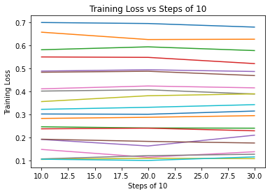

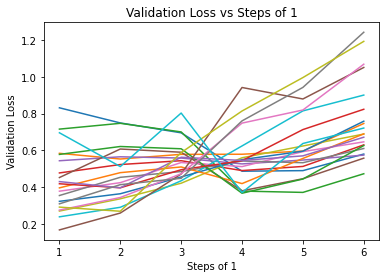

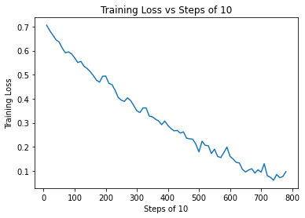

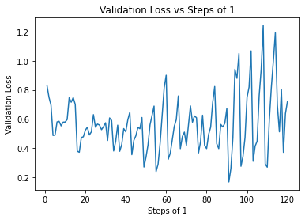

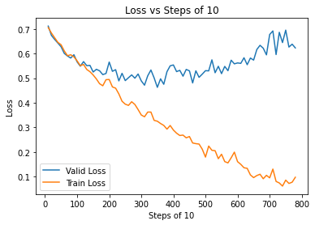

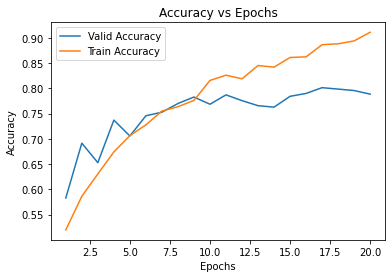

```python
net = Final_Siamese_Network().to(device)
criterion = nn.BCELoss()
optimizer = optim.Adam(net.parameters(), lr = 0.001)
num_epochs = 20
save_path = f'given_model_log.pt' # log is maintained in this saved file


TRAIN(net, train_loader, valid_loader,  num_epochs, criterion, optimizer, -float('Inf'), device, save_path)
```

```python
# loading the models
load_model = net.to(device)
load_optimizer = optim.Adam(load_model.parameters(), lr=0.001)
save_path = f'given_model_log.pt'
best_val_accuracy, train_accuracy, val_loss, train_loss = load_checkpoint(save_path, load_model, load_optimizer)

print("best_val_accuracy: ", best_val_accuracy, "train_accuracy: ", train_accuracy, "val_loss: ", val_loss, "train_loss: ", train_loss)
```

```
Model loaded from given_model_log.pt, with val accuracy: 0.8014285564422607
best_val_accuracy:  tensor(0.8014, device='cuda:0') train_accuracy:  tensor(0.8865, device='cuda:0') val_loss:  0.6208910097678503 train_loss:  0.13320829356328034
```

# 4.2.4 Evaluation

```python
def accuracy(net, predictloader):
    net.eval()
    y_pred = []
    y_test = []
    running_corrects = 0
    with torch.no_grad():
        for img1, img2, labels in predictloader:
            img1, img2, labels = img1.to(device), img2.to(device), labels.to(device)

            outputs = net(img1,img2)
            y_pred.extend(outputs.cpu().detach().numpy())
            y_test.extend(labels.cpu().detach().numpy())
        threshold = Find_Optimal_Cutoff(y_test, y_pred)[0]

        count = 0
        for i in range(len(y_pred)):
            prediction = 0
            if y_pred[i] > threshold:
                prediction = 1
            if prediction == y_test[i]:
                count += 1
        accuracy = (count / len(y_pred))
        print('Threshold: ', threshold)
        print ("Accuracy: ", (accuracy))
        return threshold, accuracy
```

```python
# optimal threshold for maximizing the accuracy
# accuracy(net, valid_loader)
```

# 4.2.5 Improving your Model

In this part, I will use A and C to improve my model

```python
#train dataset class
class CSV_Dataset_Modified(Dataset):
  #constructor
    def __init__(self, PATH, csv_file, transform = None): # PATH is assignment2 path along with the name of the csv_file that needs to be extracted
        #transformations applied
        self.transform = transform

        #file paths (train, valid, test, index)
        self.csv_path = os.path.join(PATH, csv_file)
        self.index_txt = os.path.join(PATH, 'index.txt')

        #file data (train, valid, test)
        self.csv_data = pd.read_csv(self.csv_path)

        #index.txt file content
        header_list = ["picture_num", "location"]
        self.index_content = pd.read_csv(self.index_txt, delimiter = ",", names = header_list)

        #adding 1 in front of Data
        self.index_content.loc[:, 'location'] = '1' + self.index_content.location


    def __getitem__(self, idx): # change it
        img1 = Image.open(PATH + self.index_content["location"][self.csv_data["id1"][idx] - 1])  # gets the image object from id1 of index.txt file
        img2 = Image.open(PATH + self.index_content["location"][self.csv_data["id2"][idx] - 1])  # same but for id2
        #transformations

        img1 = transforms.functional.adjust_saturation(img1, saturation_factor=1.5)
        img2 = transforms.functional.adjust_saturation(img2, saturation_factor=1.5)
        img1 = transforms.functional.adjust_sharpness(img1, sharpness_factor=1.5)
        img2 = transforms.functional.adjust_sharpness(img2, sharpness_factor=1.5)

        img1 = self.transform(img1)
        img2 = self.transform(img2)
        # label

        if self.csv_data["target"][idx] == 0 or self.csv_data["target"][idx] == 1:
            label = self.csv_data["target"][idx]
            # gets the target label i.e. 0 (if they match) or 1 (if they do not)
        else:
            label = -1  # label is not defined

        label = torch.as_tensor([label]).float()
        return img1, img2, label        #label = 0 or 1 if defined and -1 if not


    def __len__ (self):
        return len(self.csv_data)
```

```python
# Q8 C
transform = transforms.Compose(
    [
     transforms.ToTensor(),
     transforms.Grayscale(num_output_channels=1),
     transforms.Normalize((0.5, ), (0.5, )), # channel=（channel-mean）/std  -> [-1, 1]
     transforms.RandomPerspective(),
     transforms.CenterCrop((32,32))
    ])
```

```python
train_dataset = CSV_Dataset_Modified(PATH, 'train.csv', transform)
valid_dataset = CSV_Dataset_Modified(PATH, 'valid.csv', transform)
test_dataset = CSV_Dataset_Modified(PATH, 'test.csv', transform)
```

```python
bs = 128 # batch size

train_loader_mod = DataLoader(train_dataset, batch_size=bs, shuffle=True, num_workers=4, pin_memory=True)
valid_loader_mod = DataLoader(valid_dataset, batch_size=bs, shuffle=False, num_workers=4, pin_memory=True)
test_loader_mod = DataLoader(test_dataset, batch_size=1, shuffle=False)
```

```python
#model
# (1x32x32)-> conv -> conv -> max pooling -> conv (64 kernels) -> conv (128 kernels) -> conv (256) -> conv (512)
# avg pooling (16*16 kernel size) -> flattening  -> output (1*512 vector)

d_in = 512
class Siamese_Network_Modified(nn.Module):
    def __init__(self):
        super(Siamese_Network_Modified, self).__init__()

        # (32x32x1)-> conv -> (32x32x32) -> conv -> (32x32x32) ->  maxpool -> (16x16x32)
        # conv -> (16x16x64)-> conv (16x16x128) -> conv (16x16x256) -> conv (16x16x512)
        # avgpool -> (16x16x512) -> fc -> (1x1x512)
        self.conv1 = nn.Conv2d(in_channels=1, out_channels=32, kernel_size=3, padding=1, stride=1)
        self.conv2 = nn.Conv2d(in_channels=32, out_channels=32, kernel_size=3, padding=1, stride=1)

        # max pooling
        self.max_pool = nn.MaxPool2d(2, stride=2)

        self.conv3 = nn.Conv2d(in_channels=32, out_channels=64, kernel_size=3, padding=1, stride=1)
        self.conv4 = nn.Conv2d(in_channels=64, out_channels=128, kernel_size=3, padding=1, stride=1)
        self.conv5 = nn.Conv2d(in_channels=128, out_channels=256, kernel_size=3, padding=1, stride=1)
        self.conv6 = nn.Conv2d(in_channels=256, out_channels=512, kernel_size=3, padding=1, stride=1)

        # average pooling
        self.avg_pool = nn.AvgPool2d(16, stride=1)

        # batch normalization
        self.norm1 = nn.BatchNorm2d(32)
        self.norm2 = nn.BatchNorm2d(32)
        self.norm3 = nn.BatchNorm2d(64)
        self.norm4 = nn.BatchNorm2d(128)
        self.norm5 = nn.BatchNorm2d(256)
        self.norm6 = nn.BatchNorm2d(512)

        # fully connected and dropout layers
        self.fc1 = nn.Linear(d_in, d_in)
        self.drop = nn.Dropout(0.5)
        self.fc2 = nn.Linear(d_in, 1)


    # takes two input vector of size 512 and outputs the element wise absolute difference
    def aggregation(in_vec1, in_vec2):
        out_vector = abs(in_vec1 - in_vec2)
        return out_vector

    def forward(self, img1, img2):
        #  1, 32, 32
        # out_dim = in_dim - kernel_size + 1

        img1 = F.relu((self.norm1(self.conv1(img1)))) #32, 32, 32
        img1 = self.max_pool(F.relu(self.norm2(self.conv2(img1)))) #16, 16, 32
        img1 = F.relu(self.norm3(self.conv3(img1)))
        img1 = F.relu(self.norm4(self.conv4(img1)))
        img1 = F.relu(self.norm5(self.conv5(img1)))
        img1 = self.avg_pool(F.relu(self.norm6(self.conv6(img1))))
        img1 = img1.view(-1, 1 * 512)  #flatten the data

        img2 = F.relu((self.norm1(self.conv1(img2)))) #32, 32, 32
        img2 = self.max_pool(F.relu(self.norm2(self.conv2(img2)))) #16, 16, 32
        img2 = F.relu(self.norm3(self.conv3(img2)))
        img2 = F.relu(self.norm4(self.conv4(img2)))
        img2 = F.relu(self.norm5(self.conv5(img2)))
        img2 = self.avg_pool(F.relu(self.norm6(self.conv6(img2))))
        img2 = img2.view(-1, 1 * 512)  #flatten the data

        aggregate_output = aggregation(img1, img2)
#         print(aggregate_output, aggregate_output.shape)
        aggregate_output = F.relu(self.fc1(aggregate_output))
        aggregate_ouput = self.drop(aggregate_output)
        output_layer = self.fc2(aggregate_output)
        output_layer = torch.sigmoid(output_layer) # therefore bcloss should be used

        return output_layer
```